# Simulação de dados: ensaio de fungicida em soja

- Mostrar o código
- Esconder o código
- Ver o código fonte

Como gerar dados experimentais com estrutura realista em R

Autor

Jennifer Luz Lopes

Data de Publicação

09/04/2026

**Exibir código**

```r
library(tidyverse)

cores_cafe <- c(
  azul_escuro = "#224573",
  marrom      = "#6B4F4F",
  azul_claro  = "#4A6FA5",
  bege        = "#E5D3B3"
)
```

**Sobre este relatório**

Este relatório documenta o processo de simulação de dados para um ensaio de eficácia de fungicida em soja. O objetivo é mostrar como construir um conjunto de dados experimental com estrutura realista em R, partindo de parâmetros definidos com base na literatura agronômica.

O pipeline completo é executado automaticamente a cada atualização do repositório via **GitHub Actions** e publicado no **GitHub Pages**.

## 1 Contexto

A ferrugem asiática da soja (*Phakopsora pachyrhizi*) é uma das principais doenças da cultura no Brasil. Ensaios de eficácia avaliam o desempenho de fungicidas sob diferentes doses e condições ambientais.

Simular dados com estrutura de ensaio real permite:

- Validar pipelines de análise antes de receber dados reais
- Ensinar delineamento experimental com exemplos reprodutíveis
- Testar se os modelos estatísticos recuperam os parâmetros verdadeiros

## 2 Estrutura do experimento

O ensaio segue um **delineamento em blocos casualizados completos (RCBD)** com medições repetidas no tempo.

Estrutura do delineamento experimental

| Fator | Níveis |
| --- | --- |
| Tratamento | Controle, dose baixa, dose média, dose alta |
| Bloco | 6 blocos |
| Localidade | 3 localidades |
| Tempo de avaliação | 30, 60 e 90 dias após aplicação |
| Repetições | 3 por combinação |

O total de unidades experimentais é:

**Exibir código**

```r
n_tratamentos  <- 4
n_blocos       <- 6
n_localidades  <- 3
n_tempos       <- 3
n_repeticoes   <- 3

total <- n_tratamentos * n_blocos * n_localidades * n_tempos * n_repeticoes
cat("Total de unidades experimentais:", total, "\n")
```

```
Total de unidades experimentais: 648
```

## 3 Parâmetros verdadeiros

Os efeitos verdadeiros dos tratamentos foram definidos antes da simulação. Essa prática permite verificar, após o ajuste do modelo, se os valores estimados se aproximam dos valores reais, o que valida a especificação do modelo.

### 3.1 Efeito sobre a severidade

Os efeitos estão na escala logit, que é a escala natural de modelos para dados proporcionais com distribuição beta.

**Exibir código**

```r
efeito_tratamento <- c(
  controle   =  0.00,
  dose_baixa = -0.60,
  dose_media = -1.20,
  dose_alta  = -2.00
)

tibble(
  tratamento          = names(efeito_tratamento),
  efeito_logit        = efeito_tratamento,
  proporcao_estimada  = round(plogis(0.80 + efeito_tratamento) * 100, 1)
) |>
  knitr::kable(
    col.names = c("Tratamento", "Efeito (logit)", "Severidade estimada (%)"),
    align     = "lrr"
  )
```

| Tratamento | Efeito (logit) | Severidade estimada (%) |
| --- | --- | --- |
| controle | 0.0 | 69.0 |
| dose_baixa | -0.6 | 55.0 |
| dose_media | -1.2 | 40.1 |
| dose_alta | -2.0 | 23.1 |

### 3.2 Efeito sobre a produtividade

**Exibir código**

```r
efeito_prod <- c(
  controle   =    0,
  dose_baixa =  150,
  dose_media =  320,
  dose_alta  =  450
)

tibble(
  tratamento       = names(efeito_prod),
  ganho_kgha       = efeito_prod,
  prod_estimada    = 3200 + efeito_prod
) |>
  knitr::kable(
    col.names = c("Tratamento", "Ganho (kg/ha)", "Produtividade estimada (kg/ha)"),
    align     = "lrr"
  )
```

| Tratamento | Ganho (kg/ha) | Produtividade estimada (kg/ha) |
| --- | --- | --- |
| controle | 0 | 3200 |
| dose_baixa | 150 | 3350 |
| dose_media | 320 | 3520 |
| dose_alta | 450 | 3650 |

## 4 Função de simulação

A função abaixo gera uma unidade experimental com base nos parâmetros definidos. Ela incorpora:

- **Efeito aleatório de bloco:** variação entre blocos com desvio padrão de 0,20 (escala logit)
- **Efeito aleatório de localidade:** variação entre localidades com desvio padrão de 0,35
- **Efeito do tempo:** redução linear da severidade ao longo das avaliações
- **Covariáveis ambientais:** umidade relativa e temperatura média geradas aleatoriamente
- **Variabilidade residual:** ruído gaussiano com desvio padrão de 0,15

**Exibir código**

```r
simular_ue <- function(tratamento, bloco, local, tempo, rep) {

  ef_bloco <- rnorm(1, mean = 0, sd = 0.20)
  ef_local <- rnorm(1, mean = 0, sd = 0.35)
  umidade  <- runif(1, min = 55, max = 90)
  temp_med <- runif(1, min = 18, max = 32)
  ef_tempo <- -0.015 * tempo

  logit_sev <- 0.80 +
    efeito_tratamento[tratamento] +
    ef_bloco +
    ef_local +
    ef_tempo +
    0.008 * (umidade - 70) +
    rnorm(1, mean = 0, sd = 0.15)

  prob_sev   <- plogis(logit_sev)
  severidade <- rbeta(1,
                      shape1 = prob_sev * 8,
                      shape2 = (1 - prob_sev) * 8) * 100

  produtividade <- 3200 +
    efeito_prod[tratamento] +
    ef_bloco * 80 +
    ef_local * 120 +
    0.5 * tempo +
    rnorm(1, mean = 0, sd = 90)

  tibble(
    tratamento    = tratamento,
    bloco         = bloco,
    local         = local,
    tempo_dias    = tempo,
    repeticao     = rep,
    umidade_rel   = round(umidade, 1),
    temp_media    = round(temp_med, 1),
    severidade    = round(pmax(0, pmin(100, severidade)), 2),
    produtividade = round(pmax(1500, produtividade), 1)
  )
}
```

## 5 Geração dos dados

**Exibir código**

```r
set.seed(2024)

tratamentos <- c("controle", "dose_baixa", "dose_media", "dose_alta")
blocos      <- paste0("bloco_", 1:6)
localidades <- paste0("local_", 1:3)
tempos      <- c(30, 60, 90)
repeticoes  <- 1:3

dados <- expand_grid(
  tratamento = tratamentos,
  bloco      = blocos,
  local      = localidades,
  tempo_dias = tempos,
  repeticao  = repeticoes
) |>
  pmap_dfr(function(tratamento, bloco, local, tempo_dias, repeticao) {
    simular_ue(tratamento, bloco, local, tempo_dias, repeticao)
  }) |>
  mutate(
    tratamento = factor(tratamento,
                        levels = c("controle", "dose_baixa", "dose_media", "dose_alta")),
    bloco      = factor(bloco),
    local      = factor(local),
    tempo_dias = factor(tempo_dias, levels = c(30, 60, 90))
  )

glimpse(dados)
```

```
Rows: 648
Columns: 9
$ tratamento    <fct> controle, controle, controle, controle, controle, contro…
$ bloco         <fct> bloco_1, bloco_1, bloco_1, bloco_1, bloco_1, bloco_1, bl…
$ local         <fct> local_1, local_1, local_1, local_1, local_1, local_1, lo…
$ tempo_dias    <fct> 30, 30, 30, 60, 60, 60, 90, 90, 90, 30, 30, 30, 60, 60, …
$ repeticao     <int> 1, 2, 3, 1, 2, 3, 1, 2, 3, 1, 2, 3, 1, 2, 3, 1, 2, 3, 1,…
$ umidade_rel   <dbl> 71.0, 58.9, 55.0, 85.5, 70.9, 65.7, 64.9, 59.0, 65.1, 83…
$ temp_media    <dbl> 27.8, 30.1, 18.3, 30.7, 24.9, 29.4, 18.5, 30.0, 27.4, 19…
$ severidade    <dbl> 40.76, 84.06, 78.21, 51.58, 7.82, 31.72, 19.79, 47.66, 6…
$ produtividade <dbl> 3366.7, 3260.4, 3281.5, 3100.7, 3161.7, 3228.4, 3229.4, …
```

## 6 Verificação dos dados simulados

### 6.1 Distribuição da severidade

**Exibir código**

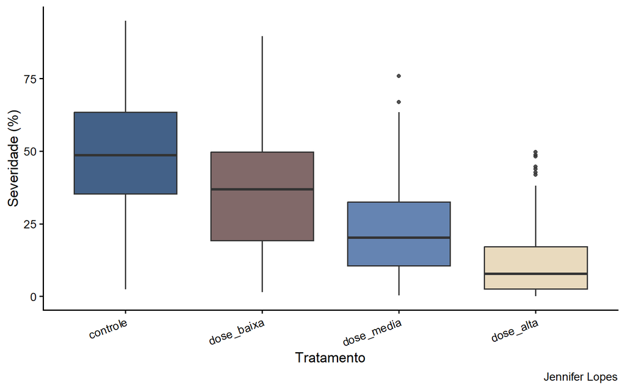

Figura 1: Distribuição da severidade por tratamento. A redução progressiva confirma que os efeitos verdadeiros foram incorporados corretamente na simulação.

```r
ggplot(dados, aes(x = tratamento, y = severidade, fill = tratamento)) +
  geom_boxplot(alpha = 0.85, outlier.size = 1.5) +
  scale_fill_manual(values = unname(cores_cafe)) +
  labs(
    x       = "Tratamento",
    y       = "Severidade (%)",
    caption = "Jennifer Lopes"
  ) +
  theme_classic(base_size = 13) +
  theme(
    legend.position = "none",
    axis.text.x     = element_text(angle = 20, hjust = 1)
  )
```

### 6.2 Evolução temporal

**Exibir código**

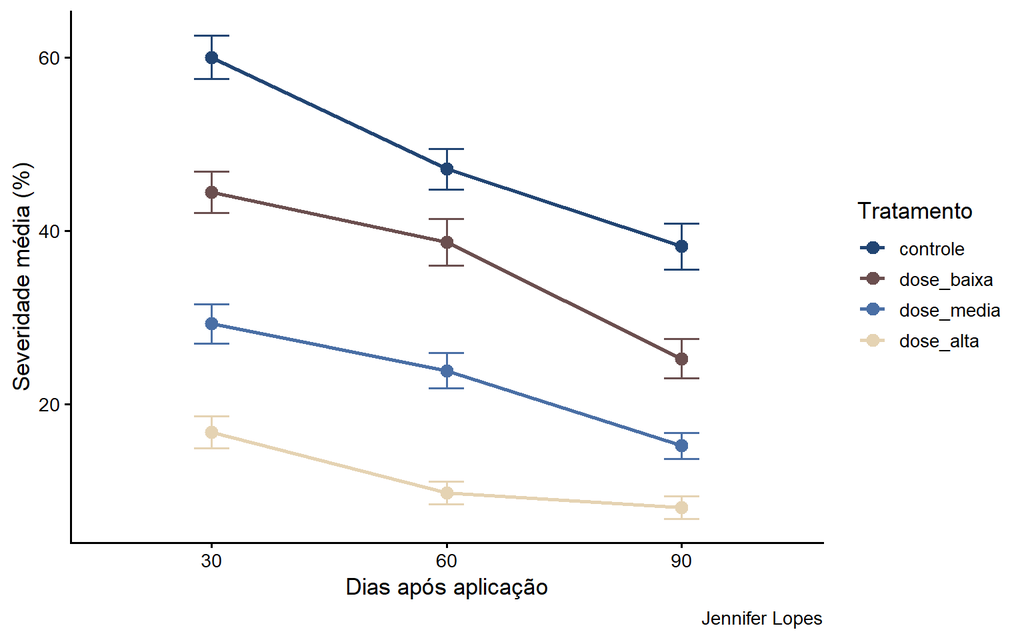

Figura 2: Evolução da severidade média por tratamento ao longo do tempo. Barras indicam erro padrão.

```r
dados |>
  group_by(tratamento, tempo_dias) |>
  summarise(
    media   = mean(severidade),
    ep      = sd(severidade) / sqrt(n()),
    .groups = "drop"
  ) |>
  ggplot(aes(x = tempo_dias, y = media,
             color = tratamento, group = tratamento)) +
  geom_line(linewidth = 0.9) +
  geom_point(size = 3) +
  geom_errorbar(aes(ymin = media - ep, ymax = media + ep),
                width = 0.15, linewidth = 0.6) +
  scale_color_manual(values = unname(cores_cafe)) +
  labs(
    x       = "Dias após aplicação",
    y       = "Severidade média (%)",
    color   = "Tratamento",
    caption = "Jennifer Lopes"
  ) +
  theme_classic(base_size = 13)
```

### 6.3 Produtividade

**Exibir código**

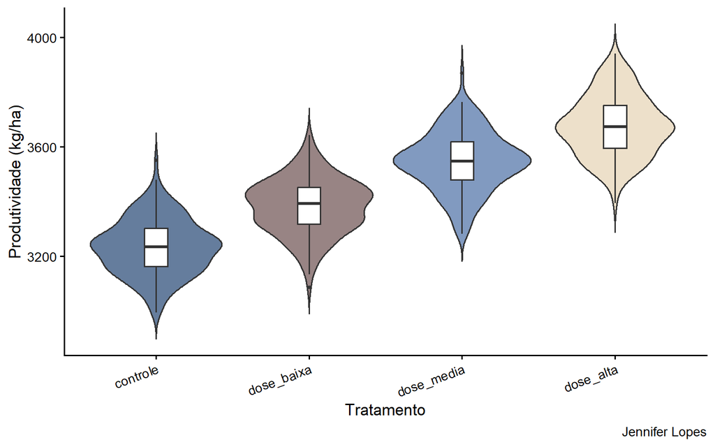

Figura 3: Produtividade por tratamento. O gradiente crescente reflete os efeitos verdadeiros definidos na simulação.

```r
ggplot(dados, aes(x = tratamento, y = produtividade, fill = tratamento)) +
  geom_violin(alpha = 0.7, trim = FALSE) +
  geom_boxplot(width = 0.15, fill = "white", outlier.size = 1) +
  scale_fill_manual(values = unname(cores_cafe)) +
  labs(
    x       = "Tratamento",
    y       = "Produtividade (kg/ha)",
    caption = "Jennifer Lopes"
  ) +
  theme_classic(base_size = 13) +
  theme(
    legend.position = "none",
    axis.text.x     = element_text(angle = 20, hjust = 1)
  )
```

### 6.4 Resumo descritivo

**Exibir código**

```r
dados |>
  group_by(tratamento) |>
  summarise(
    n             = n(),
    sev_media     = round(mean(severidade), 2),
    sev_dp        = round(sd(severidade), 2),
    prod_media    = round(mean(produtividade), 1),
    prod_dp       = round(sd(produtividade), 1),
    .groups       = "drop"
  ) |>
  knitr::kable(
    col.names = c("Tratamento", "n", "Severidade média (%)",
                  "DP severidade", "Produtividade média (kg/ha)", "DP produtividade"),
    align     = "lrrrrr"
  )
```

Tabela 1

| Tratamento | n | Severidade média (%) | DP severidade | Produtividade média (kg/ha) | DP produtividade |
| --- | --- | --- | --- | --- | --- |
| controle | 162 | 48.44 | 20.39 | 3234.7 | 101.5 |
| dose_baixa | 162 | 36.11 | 19.69 | 3383.1 | 101.2 |
| dose_media | 162 | 22.76 | 15.46 | 3547.6 | 108.5 |
| dose_alta | 162 | 11.51 | 11.63 | 3676.4 | 111.5 |

## 7 Reprodutibilidade

Este relatório é gerado automaticamente pelo GitHub Actions a cada push no repositório. O pipeline completo, da simulação ao relatório, roda em ambiente Ubuntu com R e pacotes instalados via Posit Package Manager.

Para reproduzir localmente:

```r
source("R/01_simular_dados.R")
quarto::quarto_render("report/relatorio_simulacao.qmd")
```

## 8 Informações da sessão

**Exibir código**